# Evaluación Interactiva de Matemáticas ICFES

La gráfica muestra información de las poblaciones de 5 países desde 1970 hasta 2020.

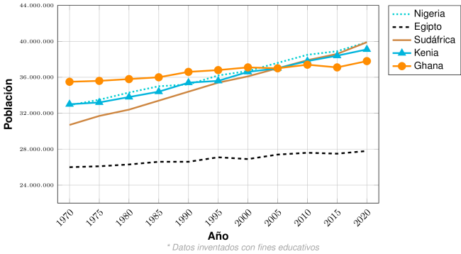

Los datos representan la evolución demográfica de diferentes naciones a lo largo de varias décadas, mostrando distintas tendencias de crecimiento poblacional.

Aproximadamente, ¿en qué año las poblaciones de **Sudáfrica** y **Ghana** fueron iguales?

2015199520052020

Para resolver este problema, debemos identificar el punto donde las líneas de **Sudáfrica** y **Ghana** se intersectan en la gráfica.

**Análisis visual de las tendencias:**

- **Sudáfrica**: Inicia con una población menor pero presenta un crecimiento más acelerado.
- **Ghana**: Comienza con una población mayor pero su crecimiento es más moderado.

**Identificación del punto de intersección:**

Observando cuidadosamente la gráfica, las dos líneas se cruzan aproximadamente en el año **2005**, donde ambas poblaciones alcanzan un valor similar de aproximadamente 37.000.000 habitantes.

**Verificación:**

- Antes de 2005: Ghana > Sudáfrica
- Después de 2005: Sudáfrica > Ghana
- **Falso**. El año 2015 no corresponde al punto de intersección de las líneas.
- **Falso**. El año 1995 no corresponde al punto de intersección de las líneas.
- **Verdadero**. El año 2005 corresponde al punto de intersección visual entre las líneas de Sudáfrica y Ghana .
- **Falso**. El año 2020 no corresponde al punto de intersección de las líneas.

La gráfica muestra información de las poblaciones de 5 países desde 1980 hasta 2023.

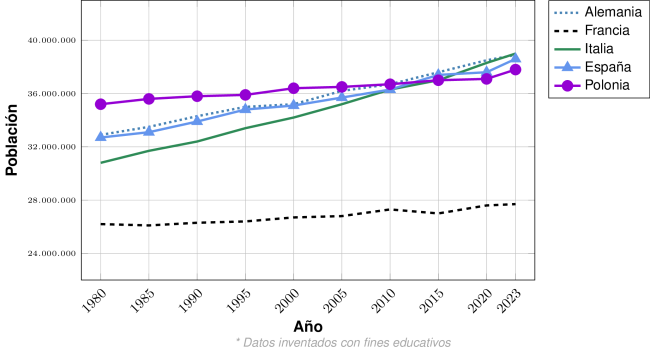

Los datos representan la evolución demográfica de diferentes naciones a lo largo de varias décadas, mostrando distintas tendencias de crecimiento poblacional.

Aproximadamente, ¿en qué año las poblaciones de **Italia** y **Polonia** fueron iguales?

2023201520051980

Para resolver este problema, debemos identificar el punto donde las líneas de **Italia** y **Polonia** se intersectan en la gráfica.

**Análisis visual de las tendencias:**

- **Italia**: Inicia con una población menor pero presenta un crecimiento más acelerado.
- **Polonia**: Comienza con una población mayor pero su crecimiento es más moderado.

**Identificación del punto de intersección:**

Observando cuidadosamente la gráfica, las dos líneas se cruzan aproximadamente en el año **2015**, donde ambas poblaciones alcanzan un valor similar de aproximadamente 37.000.000 habitantes.

**Verificación:**

- Antes de 2015: Polonia > Italia
- Después de 2015: Italia > Polonia
- **Falso**. El año 2023 no corresponde al punto de intersección de las líneas.
- **Verdadero**. El año 2015 corresponde al punto de intersección visual entre las líneas de Italia y Polonia .
- **Falso**. El año 2005 no corresponde al punto de intersección de las líneas.
- **Falso**. El año 1980 no corresponde al punto de intersección de las líneas.

La gráfica muestra información de las poblaciones de 5 países desde 1970 hasta 2020.

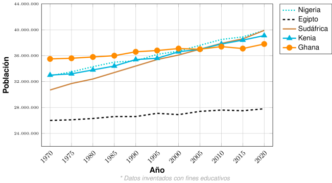

Los datos representan la evolución demográfica de diferentes naciones a lo largo de varias décadas, mostrando distintas tendencias de crecimiento poblacional.

Aproximadamente, ¿en qué año las poblaciones de **Sudáfrica** y **Ghana** fueron iguales?

2015199520052020

Para resolver este problema, debemos identificar el punto donde las líneas de **Sudáfrica** y **Ghana** se intersectan en la gráfica.

**Análisis visual de las tendencias:**

- **Sudáfrica**: Inicia con una población menor pero presenta un crecimiento más acelerado.
- **Ghana**: Comienza con una población mayor pero su crecimiento es más moderado.

**Identificación del punto de intersección:**

Observando cuidadosamente la gráfica, las dos líneas se cruzan aproximadamente en el año **2005**, donde ambas poblaciones alcanzan un valor similar de aproximadamente 37.000.000 habitantes.

**Verificación:**

- Antes de 2005: Ghana > Sudáfrica
- Después de 2005: Sudáfrica > Ghana
- **Falso**. El año 2015 no corresponde al punto de intersección de las líneas.
- **Falso**. El año 1995 no corresponde al punto de intersección de las líneas.
- **Verdadero**. El año 2005 corresponde al punto de intersección visual entre las líneas de Sudáfrica y Ghana .
- **Falso**. El año 2020 no corresponde al punto de intersección de las líneas.

La gráfica muestra información de las poblaciones de 5 países desde 1980 hasta 2023.

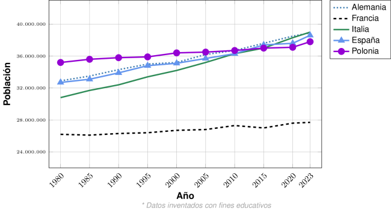

Los datos representan la evolución demográfica de diferentes naciones a lo largo de varias décadas, mostrando distintas tendencias de crecimiento poblacional.

Aproximadamente, ¿en qué año las poblaciones de **Italia** y **Polonia** fueron iguales?

2023201520051980

Para resolver este problema, debemos identificar el punto donde las líneas de **Italia** y **Polonia** se intersectan en la gráfica.

**Análisis visual de las tendencias:**

- **Italia**: Inicia con una población menor pero presenta un crecimiento más acelerado.
- **Polonia**: Comienza con una población mayor pero su crecimiento es más moderado.

**Identificación del punto de intersección:**

Observando cuidadosamente la gráfica, las dos líneas se cruzan aproximadamente en el año **2015**, donde ambas poblaciones alcanzan un valor similar de aproximadamente 37.000.000 habitantes.

**Verificación:**

- Antes de 2015: Polonia > Italia
- Después de 2015: Italia > Polonia
- **Falso**. El año 2023 no corresponde al punto de intersección de las líneas.
- **Verdadero**. El año 2015 corresponde al punto de intersección visual entre las líneas de Italia y Polonia .
- **Falso**. El año 2005 no corresponde al punto de intersección de las líneas.
- **Falso**. El año 1980 no corresponde al punto de intersección de las líneas.

La gráfica muestra información de las poblaciones de 5 países desde 1970 hasta 2020.

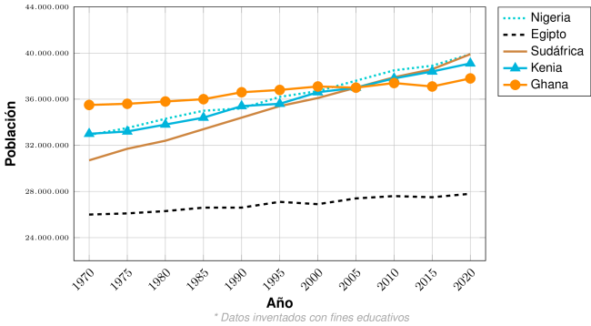

Los datos representan la evolución demográfica de diferentes naciones a lo largo de varias décadas, mostrando distintas tendencias de crecimiento poblacional.

Aproximadamente, ¿en qué año las poblaciones de **Sudáfrica** y **Ghana** fueron iguales?

2015199520052020

Para resolver este problema, debemos identificar el punto donde las líneas de **Sudáfrica** y **Ghana** se intersectan en la gráfica.

**Análisis visual de las tendencias:**

- **Sudáfrica**: Inicia con una población menor pero presenta un crecimiento más acelerado.
- **Ghana**: Comienza con una población mayor pero su crecimiento es más moderado.

**Identificación del punto de intersección:**

Observando cuidadosamente la gráfica, las dos líneas se cruzan aproximadamente en el año **2005**, donde ambas poblaciones alcanzan un valor similar de aproximadamente 37.000.000 habitantes.

**Verificación:**

- Antes de 2005: Ghana > Sudáfrica
- Después de 2005: Sudáfrica > Ghana
- **Falso**. El año 2015 no corresponde al punto de intersección de las líneas.
- **Falso**. El año 1995 no corresponde al punto de intersección de las líneas.
- **Verdadero**. El año 2005 corresponde al punto de intersección visual entre las líneas de Sudáfrica y Ghana .
- **Falso**. El año 2020 no corresponde al punto de intersección de las líneas.

La gráfica muestra información de las poblaciones de 5 países desde 1980 hasta 2023.

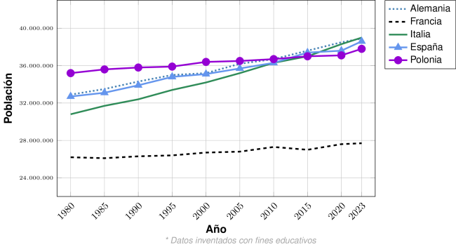

Los datos representan la evolución demográfica de diferentes naciones a lo largo de varias décadas, mostrando distintas tendencias de crecimiento poblacional.

Aproximadamente, ¿en qué año las poblaciones de **Italia** y **Polonia** fueron iguales?

2023201520051980

Para resolver este problema, debemos identificar el punto donde las líneas de **Italia** y **Polonia** se intersectan en la gráfica.

**Análisis visual de las tendencias:**

- **Italia**: Inicia con una población menor pero presenta un crecimiento más acelerado.
- **Polonia**: Comienza con una población mayor pero su crecimiento es más moderado.

**Identificación del punto de intersección:**

Observando cuidadosamente la gráfica, las dos líneas se cruzan aproximadamente en el año **2015**, donde ambas poblaciones alcanzan un valor similar de aproximadamente 37.000.000 habitantes.

**Verificación:**

- Antes de 2015: Polonia > Italia
- Después de 2015: Italia > Polonia
- **Falso**. El año 2023 no corresponde al punto de intersección de las líneas.
- **Verdadero**. El año 2015 corresponde al punto de intersección visual entre las líneas de Italia y Polonia .
- **Falso**. El año 2005 no corresponde al punto de intersección de las líneas.
- **Falso**. El año 1980 no corresponde al punto de intersección de las líneas.

La gráfica muestra información de las poblaciones de 5 países desde 1970 hasta 2020.

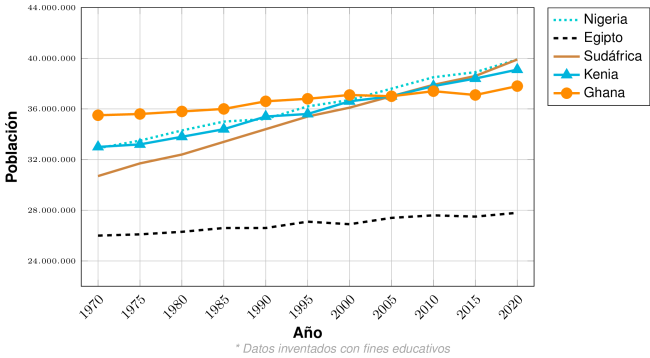

Los datos representan la evolución demográfica de diferentes naciones a lo largo de varias décadas, mostrando distintas tendencias de crecimiento poblacional.

Aproximadamente, ¿en qué año las poblaciones de **Sudáfrica** y **Ghana** fueron iguales?

2015199520052020

Para resolver este problema, debemos identificar el punto donde las líneas de **Sudáfrica** y **Ghana** se intersectan en la gráfica.

**Análisis visual de las tendencias:**

- **Sudáfrica**: Inicia con una población menor pero presenta un crecimiento más acelerado.
- **Ghana**: Comienza con una población mayor pero su crecimiento es más moderado.

**Identificación del punto de intersección:**

Observando cuidadosamente la gráfica, las dos líneas se cruzan aproximadamente en el año **2005**, donde ambas poblaciones alcanzan un valor similar de aproximadamente 37.000.000 habitantes.

**Verificación:**

- Antes de 2005: Ghana > Sudáfrica
- Después de 2005: Sudáfrica > Ghana
- **Falso**. El año 2015 no corresponde al punto de intersección de las líneas.
- **Falso**. El año 1995 no corresponde al punto de intersección de las líneas.
- **Verdadero**. El año 2005 corresponde al punto de intersección visual entre las líneas de Sudáfrica y Ghana .
- **Falso**. El año 2020 no corresponde al punto de intersección de las líneas.

La gráfica muestra información de las poblaciones de 5 países desde 1980 hasta 2023.

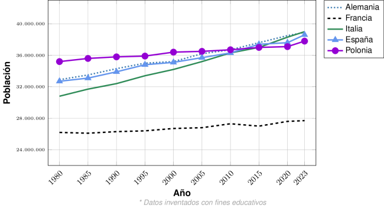

Los datos representan la evolución demográfica de diferentes naciones a lo largo de varias décadas, mostrando distintas tendencias de crecimiento poblacional.

Aproximadamente, ¿en qué año las poblaciones de **Italia** y **Polonia** fueron iguales?

2023201520051980

Para resolver este problema, debemos identificar el punto donde las líneas de **Italia** y **Polonia** se intersectan en la gráfica.

**Análisis visual de las tendencias:**

- **Italia**: Inicia con una población menor pero presenta un crecimiento más acelerado.
- **Polonia**: Comienza con una población mayor pero su crecimiento es más moderado.

**Identificación del punto de intersección:**

Observando cuidadosamente la gráfica, las dos líneas se cruzan aproximadamente en el año **2015**, donde ambas poblaciones alcanzan un valor similar de aproximadamente 37.000.000 habitantes.

**Verificación:**

- Antes de 2015: Polonia > Italia
- Después de 2015: Italia > Polonia
- **Falso**. El año 2023 no corresponde al punto de intersección de las líneas.
- **Verdadero**. El año 2015 corresponde al punto de intersección visual entre las líneas de Italia y Polonia .
- **Falso**. El año 2005 no corresponde al punto de intersección de las líneas.
- **Falso**. El año 1980 no corresponde al punto de intersección de las líneas.

La gráfica muestra información de las poblaciones de 5 países desde 1970 hasta 2020.

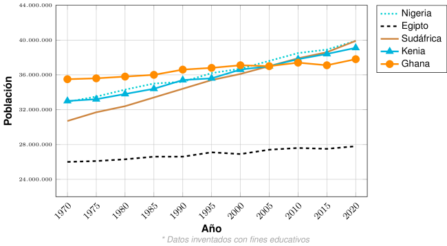

Los datos representan la evolución demográfica de diferentes naciones a lo largo de varias décadas, mostrando distintas tendencias de crecimiento poblacional.

Aproximadamente, ¿en qué año las poblaciones de **Sudáfrica** y **Ghana** fueron iguales?

2015199520052020

Para resolver este problema, debemos identificar el punto donde las líneas de **Sudáfrica** y **Ghana** se intersectan en la gráfica.

**Análisis visual de las tendencias:**

- **Sudáfrica**: Inicia con una población menor pero presenta un crecimiento más acelerado.
- **Ghana**: Comienza con una población mayor pero su crecimiento es más moderado.

**Identificación del punto de intersección:**

Observando cuidadosamente la gráfica, las dos líneas se cruzan aproximadamente en el año **2005**, donde ambas poblaciones alcanzan un valor similar de aproximadamente 37.000.000 habitantes.

**Verificación:**

- Antes de 2005: Ghana > Sudáfrica
- Después de 2005: Sudáfrica > Ghana
- **Falso**. El año 2015 no corresponde al punto de intersección de las líneas.
- **Falso**. El año 1995 no corresponde al punto de intersección de las líneas.
- **Verdadero**. El año 2005 corresponde al punto de intersección visual entre las líneas de Sudáfrica y Ghana .
- **Falso**. El año 2020 no corresponde al punto de intersección de las líneas.

La gráfica muestra información de las poblaciones de 5 países desde 1980 hasta 2023.

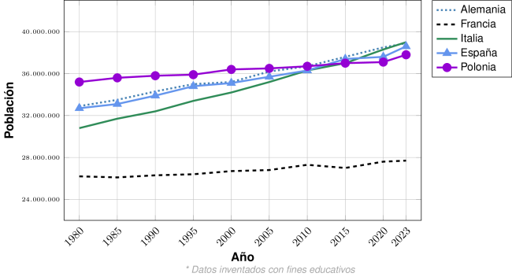

Los datos representan la evolución demográfica de diferentes naciones a lo largo de varias décadas, mostrando distintas tendencias de crecimiento poblacional.

Aproximadamente, ¿en qué año las poblaciones de **Italia** y **Polonia** fueron iguales?

2023201520051980

Para resolver este problema, debemos identificar el punto donde las líneas de **Italia** y **Polonia** se intersectan en la gráfica.

**Análisis visual de las tendencias:**

- **Italia**: Inicia con una población menor pero presenta un crecimiento más acelerado.
- **Polonia**: Comienza con una población mayor pero su crecimiento es más moderado.

**Identificación del punto de intersección:**

Observando cuidadosamente la gráfica, las dos líneas se cruzan aproximadamente en el año **2015**, donde ambas poblaciones alcanzan un valor similar de aproximadamente 37.000.000 habitantes.

**Verificación:**

- Antes de 2015: Polonia > Italia
- Después de 2015: Italia > Polonia
- **Falso**. El año 2023 no corresponde al punto de intersección de las líneas.
- **Verdadero**. El año 2015 corresponde al punto de intersección visual entre las líneas de Italia y Polonia .
- **Falso**. El año 2005 no corresponde al punto de intersección de las líneas.
- **Falso**. El año 1980 no corresponde al punto de intersección de las líneas.